# Lab 1: A Quick Start of Python

This lab material is largely self-contained. We assume that every student has already taken STAT7008 or knows some basic operations of Python. Noet that you may use Anaconda to run the .ipynb file. For the installation of Anaconda, please see https://conda.io/docs/user-guide/install/index.html.

### Purpose

In this Lab, you will learn how to:

a. Load in CSV files from the working directory.

b. Create summary statistics for exploratory data analysis.

C. Create plots, such as scatter plots and histograms.

### Useful libraries for this Lab

a. pandas, for data frame.

b. matplotlib, for plotting.

c. os, for the working directory.

```python
# import numpy as np
import pandas as pd
import matplotlib.pyplot as plt
import os

wd = os.getcwd() # Set your working directory.
print wd
```

```
/home/renjielu/PycharmProjects/DM8017/DM_Lab1
```

We load in Example.csv file from the working directory defined by the variable wd. Next, using some attributes of the data frame called df to do basic data analysis, like head and describe.

```python
df = pd.read_csv(wd+'/Example.csv')
print df.head()
print df.describe()

print '\n\n'
print df.isnull().values.any()
print 'So, no missing value exists.' # check the missing values. FALSE: no missing value.
```

```
        one       two     three      four key
0  0.467976 -0.038649 -0.295344 -1.824726   L
1 -0.358893  1.404453  0.704965 -0.200638   B
2 -0.501840  0.659254 -0.421691 -0.057688   G
3  0.204886  1.074134  1.388361 -0.982404   R
4  0.354628 -0.133116  0.283763 -0.837063   Q
                one           two         three          four
count  10000.000000  10000.000000  10000.000000  10000.000000
mean       0.045750      0.000871     -0.026463      0.015985
std        0.948825      1.003829      1.037273      0.982409
min       -3.726864     -3.465356     -3.234391     -3.173509
25%       -0.618617     -0.706643     -0.727791     -0.676291
50%        0.041638      0.018972     -0.032340     -0.005338
75%        0.701536      0.708405      0.626904      0.659369
max        2.833891      2.946737      3.053345      3.412734



False
So, no missing value exists.
```

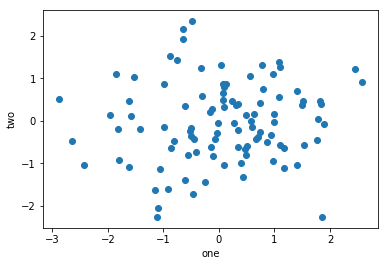

```python
plt.scatter(df.iloc[:100,1],df.iloc[:100,2]) # a scatter plot of x vs y.
plt.xlabel('one')
plt.ylabel('two')
plt.show()
```

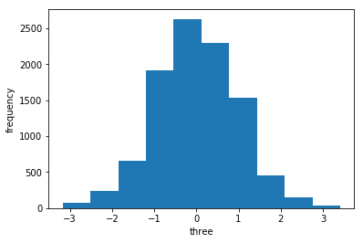

```python
plt.hist(df.iloc[:,3])
plt.xlabel('three')
plt.ylabel('frequency')
plt.show()
```

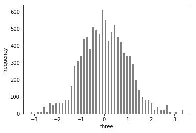

```python
plt.hist(df.iloc[:,3], bins=50, rwidth=0.5, alpha = 0.5, lw=3,color= 'k')
plt.xlabel('three')
plt.ylabel('frequency')
plt.show()
```

Finally, we add a pie chart of two pre-specified variables: F and M in the last column of the data frame called df. Note that we should compute the frequencies of F and M before we plot the pie.

```
['L' 'B' 'G' 'R' 'Q' 'U' 'K' 'S' '8' '1' 'P' 'J' 'E' 'A' 'F' 'H' 'W' 'C'
 'V' 'I' '6' 'Y' 'T' 'M' 'X' 'N' 'O' 'Z' '2' 'D' '7' '0' '4' '5' '3' '9']
```

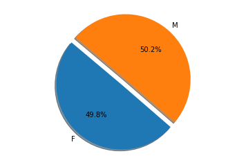

```python
labels_inkey = df['key'].unique()

print labels_inkey

labels_inkey_ = {x:0 for x in labels_inkey}

# count the frequency of each item.

for item in df['key']:
    labels_inkey_[item] += 1

# obtain the frequencies of F and M.
sizes = [labels_inkey_[item] for item in ['F','M']]

explode = [0]*len(sizes)
explode[0] = 0.1  # explode 1st slice

plt.pie(sizes, explode=explode, labels=['F','M'], autopct='%1.1f%%',
        shadow=True, startangle=140)
plt.axis('equal')
plt.show()
```